# 26__zadanie_domowe__modul_4_2__v2

## O Danych

Dane o pasażerach Titanica

Zbiór danych zawiera informacje o pasażerach RMS Titanic, który zatonął 15 kwietnia 1912 roku po zderzeniu z górą lodową. Dane obejmują takie atrybuty jak klasa podróży, wiek, płeć, liczba rodzeństwa/małżonków na pokładzie, liczba rodziców/dzieci na pokładzie, cena biletu oraz miejsce zaokrętowania.

Zbiór zawiera także informację o tym, czy pasażer przeżył katastrofę.

Titanic przewoził ponad 2,200 osób, z czego ponad 1,500 zginęło, co czyni tę katastrofę jedną z najbardziej tragicznych w historii morskiej.

Kolumny:

- **pclass** - Klasa biletu
- **survived** - Czy pasażer przeżył katastrofę
- **name** - Imię i nazwisko pasażera
- **sex** - Płeć pasażera
- **age** - Wiek pasażera
- **sibsp** - Liczba rodzeństwa/małżonków na pokładzie
- **parch** - Liczba rodziców/dzieci na pokładzie
- **ticket** - Numer biletu
- **fare** - Cena biletu
- **cabin** - Numer kabiny
- **embarked** - Port, w którym pasażer wszedł na pokład (C = Cherbourg, Q = Queenstown, S = Southampton)
- **boat** - Numer łodzi ratunkowej
- **body** - Numer ciała (jeśli pasażer nie przeżył i ciało zostało odnalezione)
- **home.dest** - Miejsce docelowe

|  | pclass | survived | name | sex | age | sibsp | parch | ticket | fare | cabin | embarked | boat | body | home.dest |
| --- | --- | --- | --- | --- | --- | --- | --- | --- | --- | --- | --- | --- | --- | --- |
| 0 | 1.0 | 1.0 | Allen, Miss. Elisabeth Walton | female | 29.0000 | 0.0 | 0.0 | 24160 | 211.3375 | B5 | S | 2 | NaN | St Louis, MO |
| 1 | 1.0 | 1.0 | Allison, Master. Hudson Trevor | male | 0.9167 | 1.0 | 2.0 | 113781 | 151.5500 | C22 C26 | S | 11 | NaN | Montreal, PQ / Chesterville, ON |
| 2 | 1.0 | 0.0 | Allison, Miss. Helen Loraine | female | 2.0000 | 1.0 | 2.0 | 113781 | 151.5500 | C22 C26 | S | NaN | NaN | Montreal, PQ / Chesterville, ON |
| 3 | 1.0 | 0.0 | Allison, Mr. Hudson Joshua Creighton | male | 30.0000 | 1.0 | 2.0 | 113781 | 151.5500 | C22 C26 | S | NaN | 135.0 | Montreal, PQ / Chesterville, ON |
| 4 | 1.0 | 0.0 | Allison, Mrs. Hudson J C (Bessie Waldo Daniels) | female | 25.0000 | 1.0 | 2.0 | 113781 | 151.5500 | C22 C26 | S | NaN | NaN | Montreal, PQ / Chesterville, ON |
| ... | ... | ... | ... | ... | ... | ... | ... | ... | ... | ... | ... | ... | ... | ... |
| 1305 | 3.0 | 0.0 | Zabour, Miss. Thamine | female | NaN | 1.0 | 0.0 | 2665 | 14.4542 | NaN | C | NaN | NaN | NaN |
| 1306 | 3.0 | 0.0 | Zakarian, Mr. Mapriededer | male | 26.5000 | 0.0 | 0.0 | 2656 | 7.2250 | NaN | C | NaN | 304.0 | NaN |
| 1307 | 3.0 | 0.0 | Zakarian, Mr. Ortin | male | 27.0000 | 0.0 | 0.0 | 2670 | 7.2250 | NaN | C | NaN | NaN | NaN |
| 1308 | 3.0 | 0.0 | Zimmerman, Mr. Leo | male | 29.0000 | 0.0 | 0.0 | 315082 | 7.8750 | NaN | S | NaN | NaN | NaN |
| 1309 | NaN | NaN | NaN | NaN | NaN | NaN | NaN | NaN | NaN | NaN | NaN | NaN | NaN | NaN |

1310 rows × 14 columns

# EDA dla danych z Tytanic

## Klient: Gotoit

[figure not shown]

### 1. Ogólny przegląd danych

#### - przegląd losowych wierszów dla danych

|  | pclass | survived | name | sex | age | sibsp | parch | ticket | fare | cabin | embarked | boat | body | home.dest |
| --- | --- | --- | --- | --- | --- | --- | --- | --- | --- | --- | --- | --- | --- | --- |
| 937 | 3.0 | 0.0 | Klasen, Miss. Gertrud Emilia | female | 1.0 | 1.0 | 1.0 | 350405 | 12.1833 | NaN | S | NaN | NaN | NaN |
| 319 | 1.0 | 1.0 | Wilson, Miss. Helen Alice | female | 31.0 | 0.0 | 0.0 | 16966 | 134.5000 | E39 E41 | C | 3 | NaN | NaN |
| 316 | 1.0 | 0.0 | Williams, Mr. Charles Duane | male | 51.0 | 0.0 | 1.0 | PC 17597 | 61.3792 | NaN | C | NaN | NaN | Geneva, Switzerland / Radnor, PA |
| 18 | 1.0 | 1.0 | Bazzani, Miss. Albina | female | 32.0 | 0.0 | 0.0 | 11813 | 76.2917 | D15 | C | 8 | NaN | NaN |
| 414 | 2.0 | 0.0 | Gale, Mr. Shadrach | male | 34.0 | 1.0 | 0.0 | 28664 | 21.0000 | NaN | S | NaN | NaN | Cornwall / Clear Creek, CO |
| 1228 | 3.0 | 1.0 | Stranden, Mr. Juho | male | 31.0 | 0.0 | 0.0 | STON/O 2. 3101288 | 7.9250 | NaN | S | 9 | NaN | NaN |
| 229 | 1.0 | 1.0 | Penasco y Castellana, Mrs. Victor de Satode (M... | female | 17.0 | 1.0 | 0.0 | PC 17758 | 108.9000 | C65 | C | 8 | NaN | Madrid, Spain |
| 693 | 3.0 | 1.0 | Buckley, Mr. Daniel | male | 21.0 | 0.0 | 0.0 | 330920 | 7.8208 | NaN | Q | 13 | NaN | Kingwilliamstown, Co Cork, Ireland New York, NY |
| 972 | 3.0 | 0.0 | Ling, Mr. Lee | male | 28.0 | 0.0 | 0.0 | 1601 | 56.4958 | NaN | S | NaN | NaN | NaN |
| 1058 | 3.0 | 0.0 | Nieminen, Miss. Manta Josefina | female | 29.0 | 0.0 | 0.0 | 3101297 | 7.9250 | NaN | S | NaN | NaN | NaN |

#### Wnioski: Dane nie są pełne, posiadają brakujące wartości szczególnie w kolumnach cabin, boat i body.

#### - analiza wartości unikatowych

```
pclass          3
survived        2
name         1307
sex             2
age            98
sibsp           7
parch           8
ticket        929
fare          281
cabin         186
embarked        3
boat           27
body          121
home.dest     369
dtype: int64
```

Kolumny:

- **pclass** - Klasa biletu
- **survived** - Czy pasażer przeżył katastrofę
- **name** - Imię i nazwisko pasażera
- **sex** - Płeć pasażera
- **age** - Wiek pasażera
- **sibsp** - Liczba rodzeństwa/małżonków na pokładzie
- **parch** - Liczba rodziców/dzieci na pokładzie
- **ticket** - Numer biletu
- **fare** - Cena biletu
- **cabin** - Numer kabiny
- **embarked** - Port, w którym pasażer wszedł na pokład (C = Cherbourg, Q = Queenstown, S = Southampton)
- **boat** - Numer łodzi ratunkowej
- **body** - Numer ciała (jeśli pasażer nie przeżył i ciało zostało odnalezione)
- **home.dest** - Miejsce docelowe

#### - podsumowanie każdej kolumny numerycznej

|  | pclass | survived | age | sibsp | parch | fare | body |
| --- | --- | --- | --- | --- | --- | --- | --- |
| count | 1309.000000 | 1309.000000 | 1046.000000 | 1309.000000 | 1309.000000 | 1308.000000 | 121.000000 |
| mean | 2.294882 | 0.381971 | 29.881135 | 0.498854 | 0.385027 | 33.295479 | 160.809917 |
| std | 0.837836 | 0.486055 | 14.413500 | 1.041658 | 0.865560 | 51.758668 | 97.696922 |
| min | 1.000000 | 0.000000 | 0.166700 | 0.000000 | 0.000000 | 0.000000 | 1.000000 |
| 25% | 2.000000 | 0.000000 | 21.000000 | 0.000000 | 0.000000 | 7.895800 | 72.000000 |
| 50% | 3.000000 | 0.000000 | 28.000000 | 0.000000 | 0.000000 | 14.454200 | 155.000000 |
| 75% | 3.000000 | 1.000000 | 39.000000 | 1.000000 | 0.000000 | 31.275000 | 256.000000 |
| max | 3.000000 | 1.000000 | 80.000000 | 8.000000 | 9.000000 | 512.329200 | 328.000000 |

#### Wnioski:

1. W podanej grubie mamy 3 klasy biletów (klasa 1 dla najzamożniejszych, klasa 2 dla średniej warstwy i klasa 3 dla imigrantów zarobkowych),
2. Nie można zidentyfikować na tym etapie najmlodszej osoby (0.166700 to prawdopodobnie jakiś błąd), najstarsza to 80 lat,
3. Średnia cena biletu: $33.3,
4. Najdroższy bilet $512.3,
5. Znaczne zróżnicowanie ceny w grubie std.dev.=$51.75,
6. 75% pasażerów zapłaciło mniej jak $31 za bilet.

### 2. Analiza brakujących wartości

#### - sumaryczna analiza brakujących wartości

```
pclass          1
survived        1
name            1
sex             1
age           264
sibsp           1
parch           1
ticket          1
fare            2
cabin        1015
embarked        3
boat          824
body         1189
home.dest     565
dtype: int64
```

#### - % analiza brakujących wartości

```
pclass        0.08
survived      0.08
name          0.08
sex           0.08
age          20.15
sibsp         0.08
parch         0.08
ticket        0.08
fare          0.15
cabin        77.48
embarked      0.23
boat         62.90
body         90.76
home.dest    43.13
dtype: float64
```

#### Wnioski:

1. W około 20% brak wieku,
2. W 90.76% brak wartości, pozostałe 10% ma numer ciała więc te osoby nie przeżyły.

### 3. Analiza pojedynczych zmiennych

```
array([[<Axes: title={'center': 'pclass'}>,
        <Axes: title={'center': 'survived'}>,
        <Axes: title={'center': 'age'}>],
       [<Axes: title={'center': 'sibsp'}>,
        <Axes: title={'center': 'parch'}>,
        <Axes: title={'center': 'fare'}>],
       [<Axes: title={'center': 'body'}>, <Axes: >, <Axes: >]],
      dtype=object)
```

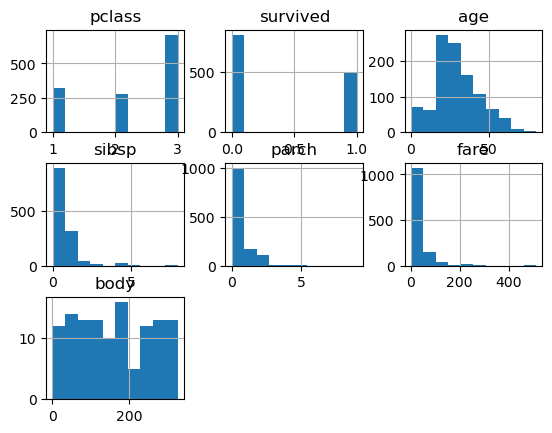

#### Wnioski:

1. Histogram 'pclass' - 50% biletów pochodzi z klasy 3, i po 25% z klasy 2 i 1,
2. Histogram 'survived' - 500 osób przetrwało, reszta 809 nie przeżyła,
3. Histogram 'age' - nie przeszedł pozytywnie testu na rozkład normalny, prawdopodobnie posiada outliery,
4. Histogram 'fare' - potwierdza, cena biletu przewżnie poniżej $50.

```
Kolumna 'age':
Rozkład nie jest normalny
```

### 4. Transformacje danych

#### Wydaje się słusznym aby naprawić dane w kolumnie age, pomoże to w analizie relacji między zmiennymi

#### - dodanie do pustych rekordów mediany ze względu na wiek

|  | pclass | survived | name | sex | age | sibsp | parch | ticket | fare | cabin | embarked | boat | body | home.dest |
| --- | --- | --- | --- | --- | --- | --- | --- | --- | --- | --- | --- | --- | --- | --- |
| 702 | 3.0 | 0.0 | Canavan, Miss. Mary | female | 21.0 | 0.0 | 0.0 | 364846 | 7.7500 | NaN | Q | NaN | NaN | NaN |
| 824 | 3.0 | 0.0 | Goncalves, Mr. Manuel Estanslas | male | 38.0 | 0.0 | 0.0 | SOTON/O.Q. 3101306 | 7.0500 | NaN | S | NaN | NaN | Portugal |
| 390 | 2.0 | 0.0 | Deacon, Mr. Percy William | male | 17.0 | 0.0 | 0.0 | S.O.C. 14879 | 73.5000 | NaN | S | NaN | NaN | NaN |
| 101 | 1.0 | 0.0 | Dulles, Mr. William Crothers | male | 39.0 | 0.0 | 0.0 | PC 17580 | 29.7000 | A18 | C | NaN | 133.0 | Philadelphia, PA |
| 474 | 2.0 | 0.0 | Kvillner, Mr. Johan Henrik Johannesson | male | 31.0 | 0.0 | 0.0 | C.A. 18723 | 10.5000 | NaN | S | NaN | 165.0 | Sweden / Arlington, NJ |
| 831 | 3.0 | 0.0 | Goodwin, Mr. Charles Frederick | male | 40.0 | 1.0 | 6.0 | CA 2144 | 46.9000 | NaN | S | NaN | NaN | Wiltshire, England Niagara Falls, NY |
| 332 | 2.0 | 0.0 | Baimbrigge, Mr. Charles Robert | male | 23.0 | 0.0 | 0.0 | C.A. 31030 | 10.5000 | NaN | S | NaN | NaN | Guernsey |
| 880 | 3.0 | 1.0 | Jalsevac, Mr. Ivan | male | 29.0 | 0.0 | 0.0 | 349240 | 7.8958 | NaN | C | 15 | NaN | NaN |
| 282 | 1.0 | 1.0 | Stephenson, Mrs. Walter Bertram (Martha Eustis) | female | 52.0 | 1.0 | 0.0 | 36947 | 78.2667 | D20 | C | 4 | NaN | Haverford, PA |
| 308 | 1.0 | 1.0 | White, Mrs. John Stuart (Ella Holmes) | female | 55.0 | 0.0 | 0.0 | PC 17760 | 135.6333 | C32 | C | 8 | NaN | New York, NY / Briarcliff Manor NY |

```
pclass          1
survived        1
name            1
sex             1
age             1
sibsp           1
parch           1
ticket          1
fare            2
cabin        1015
embarked        3
boat          824
body         1189
home.dest     565
dtype: int64
```

### 5. Analiza relacji między zmiennymi

[output not shown]

|  | pclass | survived | age | sibsp | parch | fare | body |
| --- | --- | --- | --- | --- | --- | --- | --- |
| pclass | 1.000000 | -0.312469 | -0.379761 | 0.060832 | 0.018322 | -0.558629 | -0.034642 |
| survived | -0.312469 | 1.000000 | -0.045882 | -0.027825 | 0.082660 | 0.244265 | NaN |
| age | -0.379761 | -0.045882 | 1.000000 | -0.191321 | -0.126307 | 0.179805 | 0.059114 |
| sibsp | 0.060832 | -0.027825 | -0.191321 | 1.000000 | 0.373587 | 0.160238 | -0.099961 |
| parch | 0.018322 | 0.082660 | -0.126307 | 0.373587 | 1.000000 | 0.221539 | 0.051099 |
| fare | -0.558629 | 0.244265 | 0.179805 | 0.160238 | 0.221539 | 1.000000 | -0.043110 |
| body | -0.034642 | NaN | 0.059114 | -0.099961 | 0.051099 | -0.043110 | 1.000000 |

### 6. Analiza wartości odstających

|  | pclass | survived | name | sex | age | sibsp | parch | ticket | fare | cabin | embarked | boat | body | home.dest |
| --- | --- | --- | --- | --- | --- | --- | --- | --- | --- | --- | --- | --- | --- | --- |
| 251 | 1.0 | 1.0 | Ryerson, Miss. Susan Parker "Suzette" | female | 21.0 | 2.0 | 2.0 | PC 17608 | 262.3750 | B57 B59 B63 B66 | C | 4 | NaN | Haverford, PA / Cooperstown, NY |
| 379 | 2.0 | 1.0 | Collyer, Mrs. Harvey (Charlotte Annie Tate) | female | 31.0 | 1.0 | 1.0 | C.A. 31921 | 26.2500 | NaN | S | 14 | NaN | Bishopstoke, Hants / Fayette Valley, ID |
| 1157 | 3.0 | 0.0 | Rosblom, Mr. Viktor Richard | male | 18.0 | 1.0 | 1.0 | 370129 | 20.2125 | NaN | S | NaN | NaN | NaN |
| 1299 | 3.0 | 0.0 | Yasbeck, Mr. Antoni | male | 27.0 | 1.0 | 0.0 | 2659 | 14.4542 | NaN | C | C | NaN | NaN |
| 765 | 3.0 | 1.0 | Dean, Mrs. Bertram (Eva Georgetta Light) | female | 33.0 | 1.0 | 2.0 | C.A. 2315 | 20.5750 | NaN | S | 10 | NaN | Devon, England Wichita, KS |

#### - Analiza outlierów dla kolumny wiek i cena biletu

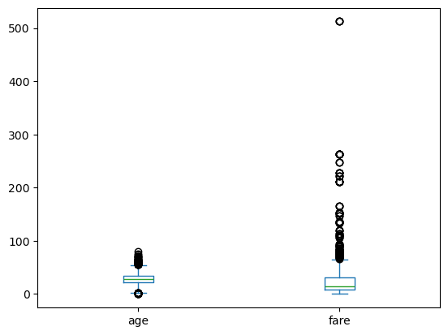

|  | pclass | sex | age min | age max | age mean | fare min | fare max | fare mean |
| --- | --- | --- | --- | --- | --- | --- | --- | --- |
| 0 | 1.0 | female | 2.0000 | 76.0 | 36.270833 | 25.70 | 512.3292 | 109.412385 |
| 1 | 1.0 | male | 0.9167 | 80.0 | 38.991155 | 0.00 | 512.3292 | 69.888385 |
| 2 | 2.0 | female | 0.9167 | 60.0 | 27.485063 | 10.50 | 65.0000 | 23.234827 |
| 3 | 2.0 | male | 0.6667 | 70.0 | 30.601364 | 0.00 | 73.5000 | 19.904946 |
| 4 | 3.0 | female | 0.1667 | 63.0 | 23.611883 | 6.75 | 69.5500 | 15.324250 |
| 5 | 3.0 | male | 0.3333 | 74.0 | 26.557471 | 0.00 | 69.5500 | 12.415462 |

```
1211
```

```
5
```

|  | pclass | survived | name | sex | age | sibsp | parch | ticket | fare | cabin | embarked | boat | body | home.dest |
| --- | --- | --- | --- | --- | --- | --- | --- | --- | --- | --- | --- | --- | --- | --- |
| 548 | 2.0 | 1.0 | Richards, Master. George Sibley | male | 0.8333 | 1.0 | 1.0 | 29106 | 18.7500 | NaN | S | 4 | NaN | Cornwall / Akron, OH |
| 590 | 2.0 | 1.0 | West, Miss. Barbara J | female | 0.9167 | 1.0 | 2.0 | C.A. 34651 | 27.7500 | NaN | S | 10 | NaN | Bournmouth, England |
| 611 | 3.0 | 1.0 | Aks, Master. Philip Frank | male | 0.8333 | 0.0 | 1.0 | 392091 | 9.3500 | NaN | S | 11 | NaN | London, England Norfolk, VA |
| 658 | 3.0 | 1.0 | Baclini, Miss. Helene Barbara | female | 0.7500 | 2.0 | 1.0 | 2666 | 19.2583 | NaN | C | C | NaN | Syria New York, NY |
| 1111 | 3.0 | 0.0 | Peacock, Master. Alfred Edward | male | 0.7500 | 1.0 | 1.0 | SOTON/O.Q. 3101315 | 13.7750 | NaN | S | NaN | NaN | NaN |

#### Wnioski:

1. Minimalny wiek stanowi pewną zagadkę, wartości < 1 mogę być albo błędami lub są to dzieci faktycznie poniżej 1 roku życia, analiza kolumny parch wskazuje, że są to dzieci ponieważ miały rodziców na pokładzie, analiza duplikatów ze względu na wiek pokazała, że są to inne osoby,
2. Najstarsze osoby występują w grupie 1, kolejno w grupie 3 i na koncu w grupie 2,
3. Średnie wartości wieku najwyższe są w clasie 1 poźniej 2 i na końcu w kasie 3,
4. Minimalne i średnie ceny biletów w sposób jasny pokazują klasę w jakiej się podróżuje, natomiast ciekawe jest zróżnicowanie ceny max dla klasy 2 i 3, nie ma znaczącej różnicy dla mężczyzn 73.5 vs 69.5 (dlaczego by nie doplacic i podróżować lepiej?), kobiety w klasie 2 cena max. niższa jak w klasie 3?

### 7. Discord chellange

|  | pclass | survived | name | sex | age | sibsp | parch | ticket | fare | cabin | embarked | boat | body | home.dest |
| --- | --- | --- | --- | --- | --- | --- | --- | --- | --- | --- | --- | --- | --- | --- |
| 196 | 1.0 | 1.0 | Marechal, Mr. Pierre | male | 28.0 | 0.0 | 0.0 | 11774 | 29.7 | C47 | C | 7 | NaN | Paris, France |

#### - grupowanie klasa vs przeżywalność w liczbach

|  | pclass | survived |
| --- | --- | --- |
| 0 | 1.0 | 200.0 |
| 1 | 2.0 | 119.0 |
| 2 | 3.0 | 181.0 |

[output not shown]

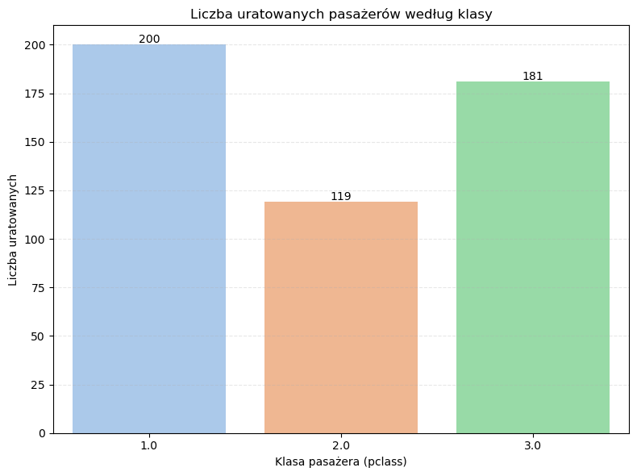

#### Wnioski: W liczbach bezwględnych klasa 2 jest dyskryminowana na konto klasy 1 i 3

#### - grupowanie płeć vs przeżywalność w klasach

|  | pclass | sex | survived |
| --- | --- | --- | --- |
| 0 | 1.0 | female | 139.0 |
| 1 | 1.0 | male | 61.0 |
| 2 | 2.0 | female | 94.0 |
| 3 | 2.0 | male | 25.0 |
| 4 | 3.0 | female | 106.0 |
| 5 | 3.0 | male | 75.0 |

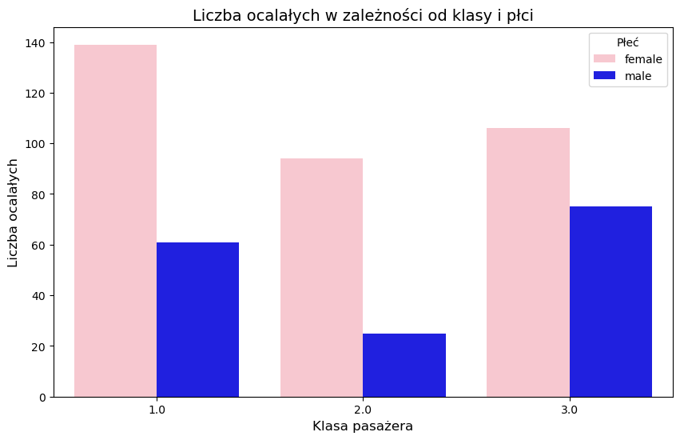

#### Wnioski: W każdej klasie faworyzowano kobiety, tutaj nie ma niespodzianki.

#### - grupowanie wiek vs przeżywalność w zakresach 10 lat

```
  age_group    sum  count  survival_rate
0      0-10   50.0     82          60.98
1     11-20   56.0    143          39.16
2     21-30  200.0    607          32.95
3     31-40   98.0    232          42.24
4     41-50   52.0    135          38.52
5     51-60   32.0     70          45.71
6     61-70   10.0     32          31.25
7     71-80    1.0      7          14.29
```

[output not shown]

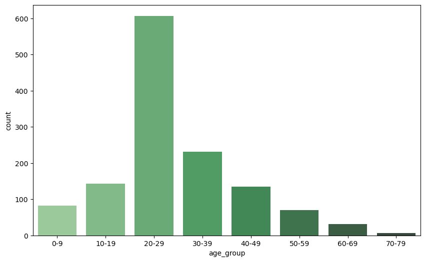

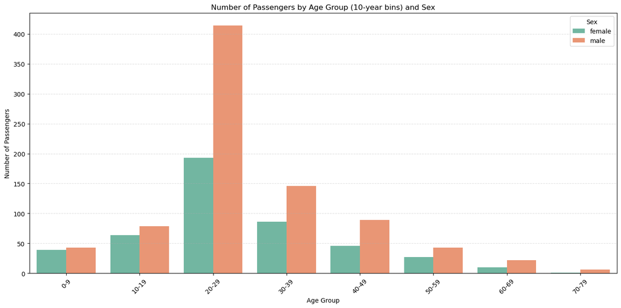

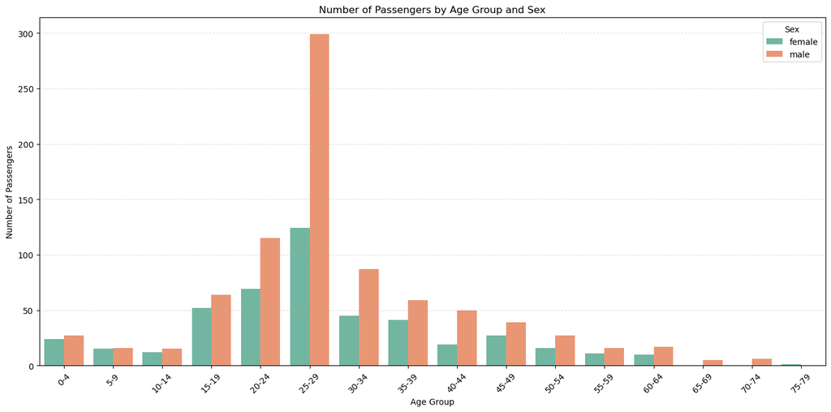

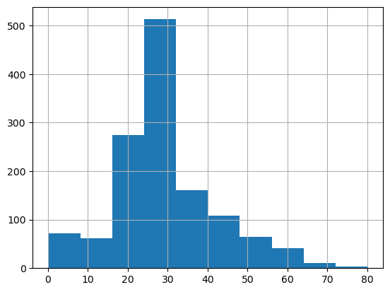

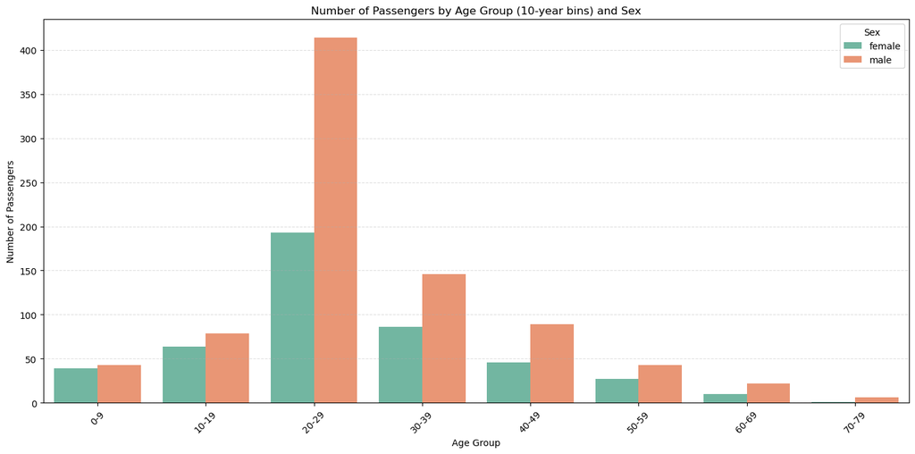

|  | pclass | survived | name | sex | age | sibsp | parch | ticket | fare | cabin | embarked | boat | body | home.dest | age_group |
| --- | --- | --- | --- | --- | --- | --- | --- | --- | --- | --- | --- | --- | --- | --- | --- |
| 378 | 2.0 | 0.0 | Collyer, Mr. Harvey | male | 31.0 | 1.0 | 1.0 | C.A. 31921 | 26.2500 | NaN | S | NaN | NaN | Bishopstoke, Hants / Fayette Valley, ID | 30-39 |
| 619 | 3.0 | 0.0 | Allum, Mr. Owen George | male | 18.0 | 0.0 | 0.0 | 2223 | 8.3000 | NaN | S | NaN | 259.0 | Windsor, England New York, NY | 10-19 |
| 369 | 2.0 | 0.0 | Chapman, Mrs. John Henry (Sara Elizabeth Lawry) | female | 29.0 | 1.0 | 0.0 | SC/AH 29037 | 26.0000 | NaN | S | NaN | NaN | Cornwall / Spokane, WA | 20-29 |
| 893 | 3.0 | 0.0 | Johansson, Mr. Nils | male | 29.0 | 0.0 | 0.0 | 347467 | 7.8542 | NaN | S | NaN | NaN | NaN | 20-29 |
| 1190 | 3.0 | 1.0 | Sap, Mr. Julius | male | 25.0 | 0.0 | 0.0 | 345768 | 9.5000 | NaN | S | 11 | NaN | NaN | 20-29 |

|  | age_group | sex | count |
| --- | --- | --- | --- |
| 0 | 0-9 | female | 39 |
| 1 | 0-9 | male | 43 |
| 2 | 10-19 | female | 64 |
| 3 | 10-19 | male | 79 |
| 4 | 20-29 | female | 193 |
| 5 | 20-29 | male | 414 |
| 6 | 30-39 | female | 86 |
| 7 | 30-39 | male | 146 |
| 8 | 40-49 | female | 46 |
| 9 | 40-49 | male | 89 |
| 10 | 50-59 | female | 27 |
| 11 | 50-59 | male | 43 |
| 12 | 60-69 | female | 10 |
| 13 | 60-69 | male | 22 |
| 14 | 70-79 | female | 1 |
| 15 | 70-79 | male | 6 |

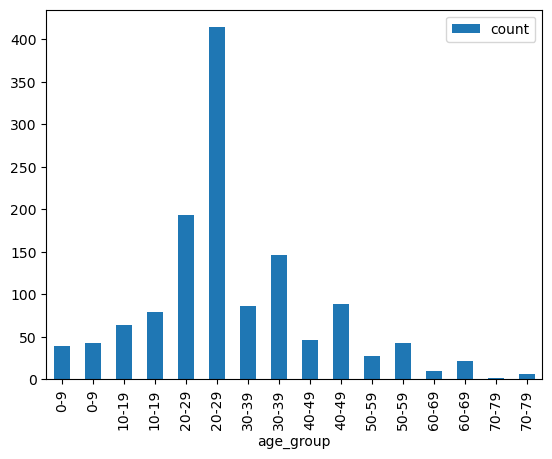

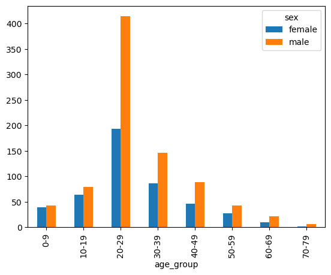